# Notas - Obligatorio

# Notas

En este documento se incluyen las notas para la creación del obligatorio de la materia “Introducción a la Programación para Analítica”.

## Importar datos desde archivos de Excel

Podemos usar el paquete `readxl`.

Primero debemos instalarlo:

```r
install.packages("readxl")
```

Luego cargarlo a nuestra sesión:

```r
library(readxl)
```

La librería trae una función llamada `read_excel()` que permite leer archivo `xls` y `xlsx`.

En nuestro caso el nombre del archivo de Excel que queremos importar se llama `Obligatorio.xlsx`.

```r
data = read_excel('./Obligatorio.xlsx')
```

## Algunas funciones de ayuda

Coloco el prefijo `gi` adelante de las funciones para no sobrescribir ninguna función global.

Para que funcionen estas funcione es necesario instalar los siguientes módulos:

```r
install.packages("circlize")
install.packages("tidyr")
```

Y debemos cargarlos.

```r
library(circlize)
library(tidyr)
```

### `gi_bar_chart`

Función para crear gráficos de barras. Tiene un estilo sencillo y selecciona la paleta de colores de forma automatica basada en el color azul.

```r
gi_bar_chart = function (x, y, main="", legend = FALSE) {
  # Random colors
  colors = circlize::rand_color(length(x), hue = 'blue')
  # Basic Barplot
  my_bar = barplot(
    height = y,
    names.arg = x,
    border = NA,
    col = colors,
    main = main
  )
  # Add the text
  text(x = my_bar, y = y, labels = y, pos = 1, col = rgb(1, 1, 1))
}
```

### `gi_summarize_by`

Función para agrupar y contar los datos según alguna de las columnas. Es necesario pasarle una lista de nombres para intercambiar por los valores en el eje `x`.

```r
gi_summarize_by = function(data, attribute, lista) {
  data %>%
    select(ID, (!!as.name(attribute))) %>%
    group_by(ID) %>%
    summarize(
      tipo = lista[dplyr::first((!!as.name(attribute)))],
      id = dplyr::first((!!as.name(attribute)))
    ) %>%
    group_by(tipo) %>%
    summarize(cuenta = n(), id = dplyr::first(id)) %>%
    dplyr::arrange(id)
}
```

### `gi_percent`

Fomatea un número en formato de porcentaje.

```r
gi_percent <- function(x, digits = 2, format = "f", ...) {
  paste0(formatC(100 * x, format = format, digits = digits, ...), "%")
}
```

### `gi_money`

```r
gi_money <- function(x, ...) {
  paste0("$", formatC(as.numeric(x), format="f", digits=2, big.mark=","))
}
```

## Estudio preliminar de los datos

Primero debemos investigar que tipo tiene la nueva variable `data`.

```r
typeof(data)
```

```
## [1] "list"
```

```r
class(data)
```

```
## [1] "tbl_df"     "tbl"        "data.frame"
```

Es una lista con una clase que desconosco com trabajar. Sin embargo, la podemos convertir en un `data.frame`:

```r
df = as.data.frame(data)
typeof(df)
```

```
## [1] "list"
```

```r
class(df)
```

```
## [1] "data.frame"
```

Veamos la tabla.

```r
head(df)
```

```
##   ID Apellido    Nombre sexo Edad Localidad Segmento Ingresos      Fecha
## 1  1  PIAGGIO     MARIA    M    1         1        1 21170.63 2019-02-01
## 2  1  PIAGGIO     MARIA    M    1         1        1 21170.63 2019-04-01
## 3  1  PIAGGIO     MARIA    M    1         1        1 21170.63 2019-04-01
## 4  1  PIAGGIO     MARIA    M    1         1        1 21170.63 2019-05-01
## 5  2 GAGLIANO ELIZABETH    M    1         2        1 14802.48 2019-01-01
## 6  2 GAGLIANO ELIZABETH    M    1         2        1 14802.48 2019-01-01
##   Producto Tasa Prestamo Atraso Importe_Cuota Saldo_Capital Capital_Pagado
## 1        1   45    1e+05      0     10501.230      78977.30      21022.698
## 2        1   45    1e+05     34     10501.230     100000.00          0.000
## 3        2   45    5e+04      0      5250.615      46624.38       3375.615
## 4        2   45    5e+04      0      5250.615      50000.00          0.000
## 5        1   45    1e+05      0     10501.230      71437.72      28562.279
## 6        2   45    5e+04      0      5250.615      35718.86      14281.139
##   Saldo_Intereses Intereses_Pagos Cuotas_Pagas
## 1        15533.77       10480.993            3
## 2        26014.76           0.000            0
## 3        11132.38        1875.000            1
## 4        13007.38           0.000            0
## 5        12572.12       13442.642            4
## 6         6286.06        6721.321            4
```

Podemos ver que los clientes pueden tener más de un producto. Tenemos que agrupar por `id` para obtener información de cada cliente. Primero averiguemos cuantos clientes únicos tenemos.

```r
unique_clients = length((df %>%
  select(ID) %>%
  group_by(ID) %>%
  summarize() %>%
  arrange(desc(ID)))$ID)
unique_clients
```

```
## [1] 10515
```

Otra forma de ver cuantos clientes unicos tenemos es la siguiente:

```r
unique_clients = nrow(df %>%
  select(ID) %>%
  unique())
unique_clients
```

```
## [1] 10515
```

### Agrupamos por genero

```r
diccionario_de_generos = c('Masculino', 'Femenino')
names(diccionario_de_generos) = c('H', 'M')
generos = df %>%
  select(ID, sexo) %>%
  group_by(ID) %>%
  summarize(genero = diccionario_de_generos[dplyr::first(sexo)]) %>%
  group_by(genero) %>%
  summarize(cuenta = n()) %>%
  arrange(cuenta)
generos
```

```
## # A tibble: 2 x 2
##   genero    cuenta
##   <chr>      <int>
## 1 Masculino   5124
## 2 Femenino    5391
```

Graficamos los resultados

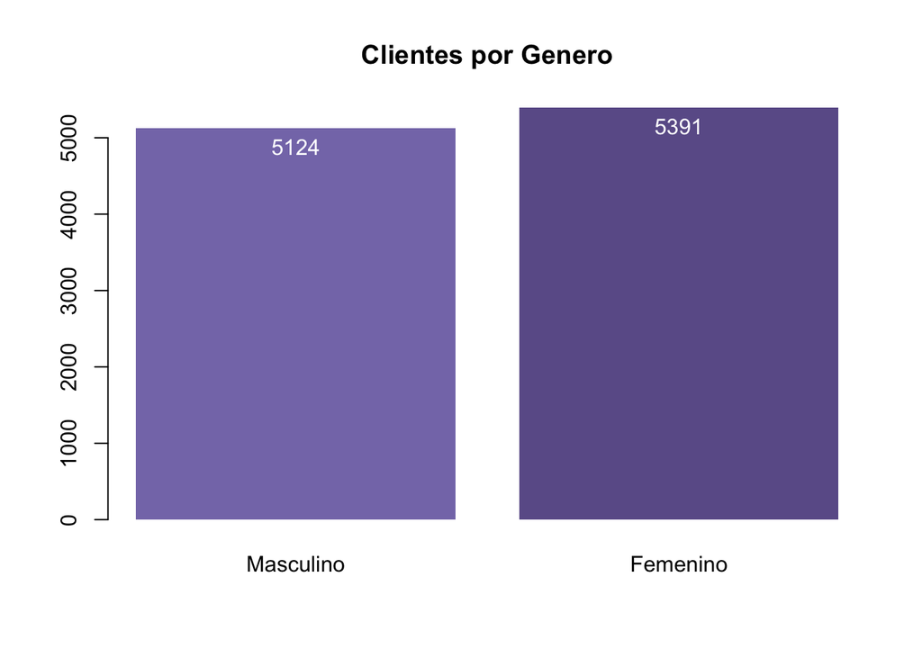

```r
gi_bar_chart(generos$genero, generos$cuenta, main = "Clientes por Genero")
```

### Agrupamos por edad

```r
id_de_edad_a_rango = c('18 a 30', '30 a 45', '45 a 60', '>60')
edades = gi_summarize_by(df, 'Edad', id_de_edad_a_rango)
edades
```

```
## # A tibble: 4 x 3
##   tipo    cuenta    id
##   <chr>    <int> <dbl>
## 1 18 a 30   2084     1
## 2 30 a 45   2133     2
## 3 45 a 60   3399     3
## 4 >60       2899     4
```

### Graficamos los resultados

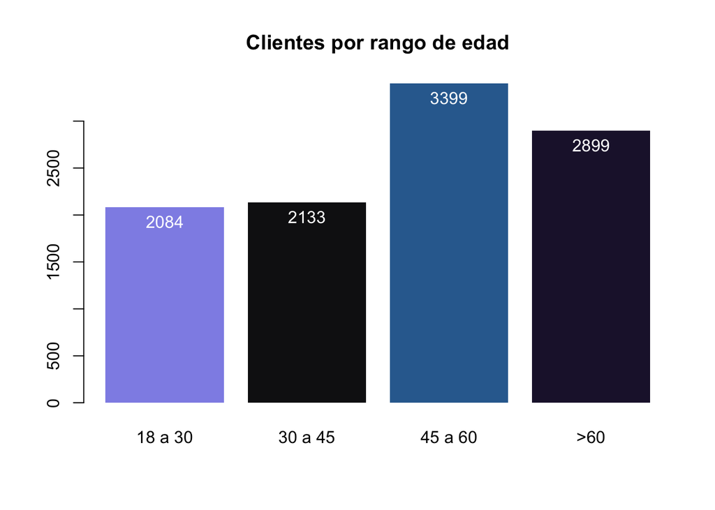

```r
gi_bar_chart(edades$tipo, edades$cuenta, main = "Clientes por rango de edad")
```

### Agrupamos por localidad

```r
id_de_localidad_a_lugar = c('Montevideo', 'Interior')
localidades = gi_summarize_by(df, 'Localidad', id_de_localidad_a_lugar)
localidades
```

```
## # A tibble: 2 x 3
##   tipo       cuenta    id
##   <chr>       <int> <dbl>
## 1 Montevideo   4787     1
## 2 Interior     5728     2
```

Graficamos los resultados

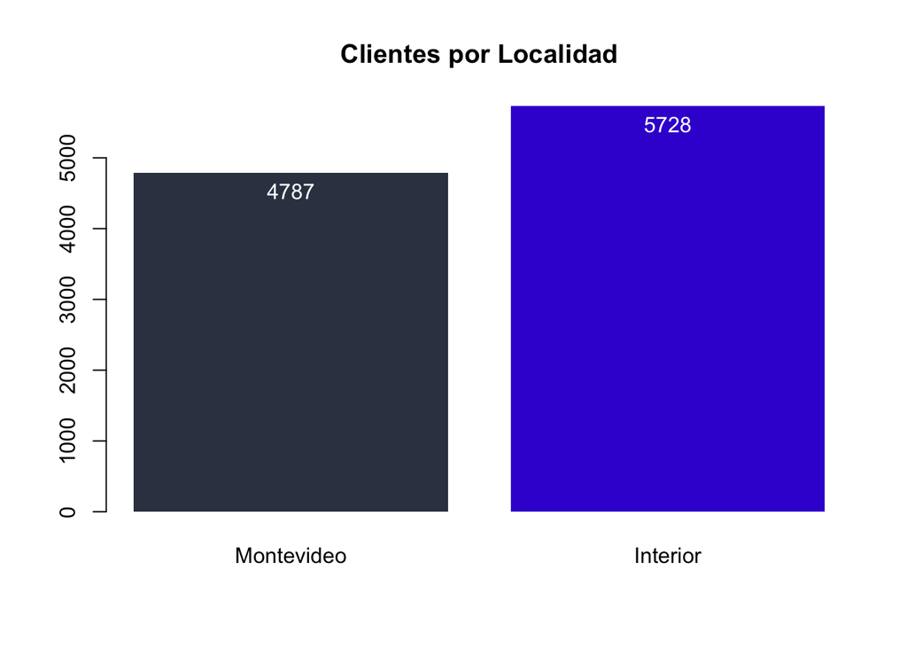

```r
gi_bar_chart(localidades$tipo, localidades$cuenta, main = "Clientes por Localidad")
```

### Agrupamos por segmento

```r
id_de_segmento_a_tipo = c('VIP', 'Regular', 'Malo')
segmentos = gi_summarize_by(df, 'Segmento', id_de_segmento_a_tipo)
segmentos
```

```
## # A tibble: 3 x 3
##   tipo    cuenta    id
##   <chr>    <int> <dbl>
## 1 VIP       1498     1
## 2 Regular   6073     2
## 3 Malo      2944     3
```

Graficamos los resultados

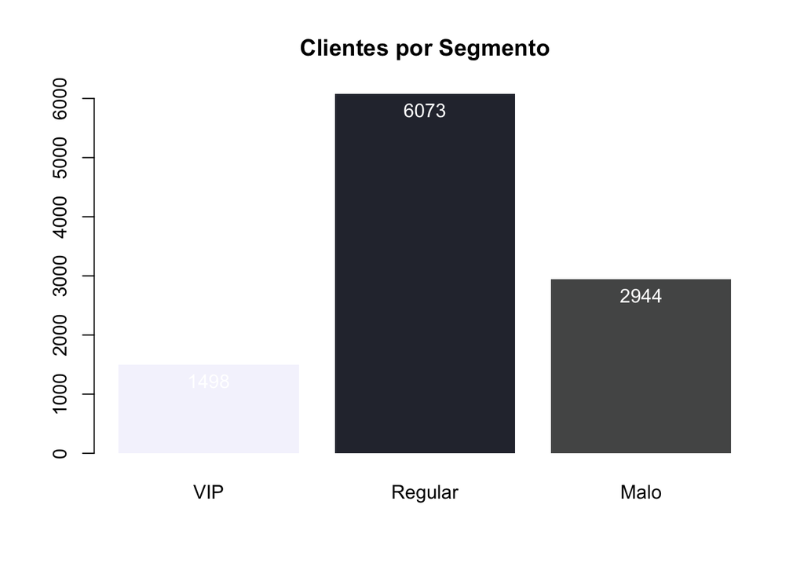

```r
gi_bar_chart(segmentos$tipo, segmentos$cuenta, main = "Clientes por Segmento")
```

```r
id_de_producto_a_tipo = c('100k en 12c', '50k en 12c', '25k en 12c', '16k en 12c')
productos = gi_summarize_by(df, 'Segmento', id_de_producto_a_tipo)
productos
```

```
## # A tibble: 3 x 3
##   tipo        cuenta    id
##   <chr>        <int> <dbl>
## 1 100k en 12c   1498     1
## 2 50k en 12c    6073     2
## 3 25k en 12c    2944     3
```

Graficamos los resultados

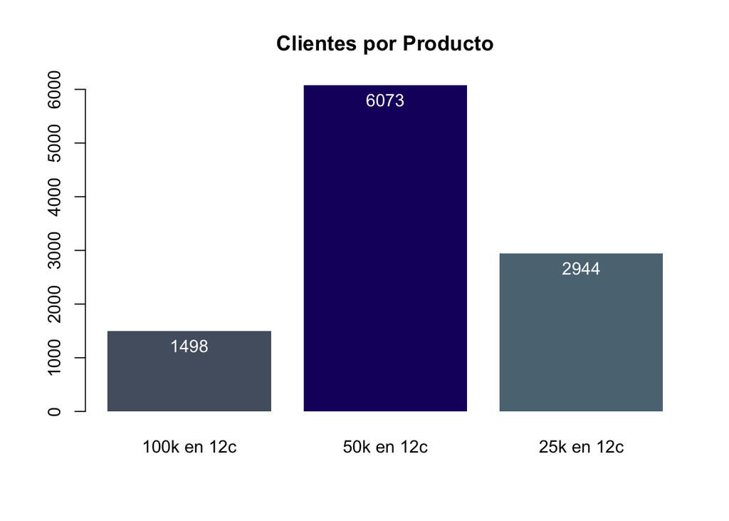

```r
gi_bar_chart(productos$tipo, productos$cuenta, main = "Clientes por Producto")
```

### Agrupaciones con más de una variable

```r
df %>%
  group_by(ID) %>%
  distinct(ID, .keep_all = TRUE) %>%
  mutate(Edad = replace(Edad, !is.na(Edad), id_de_edad_a_rango[Edad])) %>%
  group_by(sexo, Edad) %>%
  summarize(cuenta = n()) %>%
  spread(Edad, cuenta, )
```

```
## # A tibble: 2 x 5
## # Groups:   sexo [2]
##   sexo  `>60` `18 a 30` `30 a 45` `45 a 60`
##   <chr> <int>     <int>     <int>     <int>
## 1 H      1282      1330      1083      1429
## 2 M      1617       754      1050      1970
```

### Previsiones

Funcion para obtener el porcentaje a aplicar en el calculo de previsiones

```r
get_percentage = function(max_delay_days) {
  percentage = ifelse(0 <= max_delay_days & max_delay_days <= 10, 0.005,
  ifelse(11 <= max_delay_days & max_delay_days <= 30, 0.015,
  ifelse(31 <= max_delay_days & max_delay_days <= 60, 0.03,
  ifelse(61 <= max_delay_days & max_delay_days <= 120, 0.17,
  ifelse(121 <= max_delay_days & max_delay_days <= 180, 0.5, 1)))))
  return(percentage)
}
```

Calculo el resumen para cada cliente incluyendo las previsiones.

```r
customer_summary = df %>%
  group_by(ID) %>%
  summarize(apellido = first(Apellido),
            nombre = first(Nombre),
            segmento = first(Segmento),
            atraso_maximo = max(Atraso),
            prestamo = sum(Prestamo),
            capital_pagado = sum(Capital_Pagado),
            saldo_capital = sum(Saldo_Capital),
            intereses_pagos = sum(Intereses_Pagos),
            saldo_intereses = sum(Saldo_Intereses),
            prevision = sum(Saldo_Capital)*get_percentage(max(Atraso)))
```

Calculo el resumen para TuCredito

```r
company_summary = customer_summary %>%
  summarize(
    'Prestamo' = gi_money(sum(prestamo)),
    'Capital Pagado' = gi_money(sum(capital_pagado)),
    'Saldo Capital' = gi_money(sum(saldo_capital)),
    'Intereses Pagos' = gi_money(sum(intereses_pagos)),
    'Saldo de Intereses' = gi_money(sum(saldo_intereses)),
    'Previsión' = gi_money(sum(prevision)),
    # Calculo el resultado como los intereses cobrados menos la prevision
    'Resultado' = gi_money(sum(intereses_pagos) - sum(prevision)),
    # Calculo cuanto representa el resultado en lo que tengo actualmente invertido, (desde el punto de vista contable, no financiero)
    'Resultado Porcentual' = gi_percent((sum(intereses_pagos) - sum(prevision)) / sum(saldo_capital)),
  )

company_summary %>%
  t() %>%
  as.data.frame() %>%
  rename(Valores = V1) %>%
  kable(digits = 2) %>%
  kable_styling(
    bootstrap_options = c("striped", "hover", "condensed", "responsive"),
    full_width = F,
    fixed_thead = T
  )
```

|  | Valores |
| --- | --- |
| Prestamo | $2,594,062,000.00 |
| Capital Pagado | $209,591,465.37 |
| Saldo Capital | $2,384,470,534.63 |
| Intereses Pagos | $293,369,131.95 |
| Saldo de Intereses | $1,315,300,327.38 |
| Previsión | $430,440,293.85 |
| Resultado | $-137,071,161.90 |
| Resultado Porcentual | -5.75% |

[figure not shown]

```r
# Estoy trancado no me doy cuenta como graficar esto de mejor manera
barplot(as.matrix(company_summary))
```

### Analisis de segmentos

```r
segment_summary = customer_summary %>%
  select(segmento, atraso_maximo, prestamo, capital_pagado, saldo_capital, intereses_pagos, saldo_intereses, prevision) %>%
  group_by(segmento) %>%
  summarize(cantidad_de_clientes = n(),
            atraso_promedio = mean(atraso_maximo),
            prestamo = sum(prestamo),
            capital_pagado = sum(capital_pagado),
            saldo_capital = sum(saldo_capital),
            intereses_pagos = sum(intereses_pagos),
            saldo_intereses = sum(saldo_intereses),
            prevision = sum(prevision),
            resultado = sum(intereses_pagos) - sum(prevision),
            resultado_porcentual = (sum(intereses_pagos) - sum(prevision))*100/sum(saldo_capital))
head(segment_summary)
```

```
## # A tibble: 3 x 11
##   segmento cantidad_de_cli… atraso_promedio prestamo capital_pagado
##      <dbl>            <int>           <dbl>    <dbl>          <dbl>
## 1        1             1498            27.0   5.36e8      67798998.
## 2        2             6073            83.5   1.39e9      77283793.
## 3        3             2944             0     6.72e8      64508674.
## # … with 6 more variables: saldo_capital <dbl>, intereses_pagos <dbl>,
## #   saldo_intereses <dbl>, prevision <dbl>, resultado <dbl>,
## #   resultado_porcentual <dbl>
```

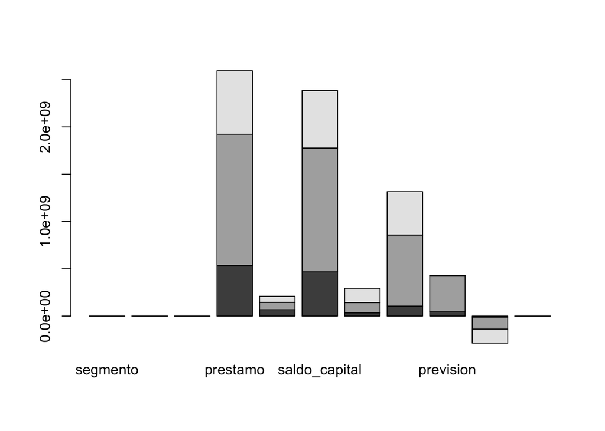

```r
# De nuevo, las graficas estan como placeholders
barplot(as.matrix(segment_summary))
```

### `xtable`

```r
library(knitr)
kable(head(df), digits = 2)
```

| ID | Apellido | Nombre | sexo | Edad | Localidad | Segmento | Ingresos | Fecha | Producto | Tasa | Prestamo | Atraso | Importe_Cuota | Saldo_Capital | Capital_Pagado | Saldo_Intereses | Intereses_Pagos | Cuotas_Pagas |
| --- | --- | --- | --- | --- | --- | --- | --- | --- | --- | --- | --- | --- | --- | --- | --- | --- | --- | --- |
| 1 | PIAGGIO | MARIA | M | 1 | 1 | 1 | 21170.63 | 2019-02-01 | 1 | 45 | 1e+05 | 0 | 10501.23 | 78977.30 | 21022.70 | 15533.77 | 10480.99 | 3 |
| 1 | PIAGGIO | MARIA | M | 1 | 1 | 1 | 21170.63 | 2019-04-01 | 1 | 45 | 1e+05 | 34 | 10501.23 | 100000.00 | 0.00 | 26014.76 | 0.00 | 0 |
| 1 | PIAGGIO | MARIA | M | 1 | 1 | 1 | 21170.63 | 2019-04-01 | 2 | 45 | 5e+04 | 0 | 5250.62 | 46624.38 | 3375.62 | 11132.38 | 1875.00 | 1 |
| 1 | PIAGGIO | MARIA | M | 1 | 1 | 1 | 21170.63 | 2019-05-01 | 2 | 45 | 5e+04 | 0 | 5250.62 | 50000.00 | 0.00 | 13007.38 | 0.00 | 0 |
| 2 | GAGLIANO | ELIZABETH | M | 1 | 2 | 1 | 14802.48 | 2019-01-01 | 1 | 45 | 1e+05 | 0 | 10501.23 | 71437.72 | 28562.28 | 12572.12 | 13442.64 | 4 |
| 2 | GAGLIANO | ELIZABETH | M | 1 | 2 | 1 | 14802.48 | 2019-01-01 | 2 | 45 | 5e+04 | 0 | 5250.62 | 35718.86 | 14281.14 | 6286.06 | 6721.32 | 4 |

### Observaciones

- La categorización del servicio fija la Tasa. Cuanto mejor es el cliente mejor es la Tasa.
- Una persona saco el prestamo el 4 de abril. Por lo que la cuota le debe haber caido en mayo. Si no paga, los días de atraso son un mes despues de la fecha de atraso. Una deuda de mayo debería tener unos 10 días.
- El saldo de capital es lo que le resta por devolver si el atraso es cero.
- El saldo de intereses es lo que me queda de intereses por cobrarle a las personas. Que es mi ganancia, basicamente.
- Para seleccionar solo las filas únicas podemos utilizar la función `unique`.
- Buscar diferencias entre múltiples variables para ver si hay diferencias. Ingreso vs Edad, Ingreso vs Genero, Ubicación, etc. También podrías decir productos promedios por persona. Cual es el capital remanente por persona.
- Buscar cuanto voy generando de plata por mes.
- Podrías hacer un gráfico que diga cuanto se genero por més, cuanto se presto, cuanto esta atrasado, y cuanto es el remanente. Lo podemos ver según tasa promedio. Podemos ver la ganancia esperada.

> La idea es ver como vengo. Decime si le estoy dando prestamos correctamente a mis clientes.
- Ahora puede ver cuanto preste, cuanto me queda por cobrar.

> La primera y la cuarta son de los 10515, mientras que la dos y la tres trata de todos los datos.

El cálculo de previsiones es sobre el máximo de atraso que tiene el cliente. Tenemos que provisionar sobre todo el saldo que nos debe. Osea el saldo.

## Notas adicionales

### Configurar la carpeta de trabajo

Para obtener la carpeta de trabajo donde estamos trabajando utilizamos la función global `getwd()`.

```r
getwd()
```

```
## [1] "/Users/gmonne/Projects/r/Obligatorio"
```

Mientras que para configurarla utilizamos la función global `setwd()`.

```r
setwd('~/Projects/r/Obligatorio')
```

**OBS: Este documento de “R markdown” esta configurado para correr por defecto en la carpeta `~/Projects/r/Obligatorio`. Esto se configura en el primer `chunk` con el resto de la configuración de `knit`. Knit es la librería utilizada para compilar el codigo `r` dentro de documento de “R Markdown”.**

### Importar datos desde archivos CSV

Para cargar archivos `csv` podemos utilizar la función global `read.csv`. En el repositorio se puede encontrar una carpeta llamada `the-simpsons-by-the-data` que cuenta con múltiples archivos `csv` con información de “Los Simpsons” obtenida de [Kagle](https://www.kaggle.com/wcukierski/the-simpsons-by-the-data/downloads/the-simpsons-by-the-data.zip/1). Para cargar la lista con los episodios debemos realizar las siguiente acciones.

```r
# La opción `quote` es para indicarle al parser como identificar
# a los datos.
episodes = read.csv('./the-simpsons-by-the-data/simpsons_episodes.csv')
# Para ver las primeras lineas
head(episodes)
```

```
##   id                                                 title
## 1 10                                     Homer's Night Out
## 2 12                                    Krusty Gets Busted
## 3 14                                      Bart Gets an "F"
## 4 17 Two Cars in Every Garage and Three Eyes on Every Fish
## 5 19                                  Dead Putting Society
## 6 21                                    Bart the Daredevil
##   original_air_date production_code season number_in_season
## 1           3/25/90            7G10      1               10
## 2           4/29/90            7G12      1               12
## 3          10/11/90            7F03      2                1
## 4           11/1/90            7F01      2                4
## 5          11/15/90            7F08      2                6
## 6           12/6/90            7F06      2                8
##   number_in_series us_viewers_in_millions views imdb_rating imdb_votes
```

[output cut: 20 more lines]

### Filtrar listas

Una forma de filtar listas es utilizando la función global `lapply`.

Por ejemplo:

```r
l = list(n1=numeric(0), n2="foo", n3=numeric(0), n4=1:5)
# Filtrar los elementos que tengan un largo igual a cero
l[lapply(l, length) > 0]
```

```
## $n2
## [1] "foo"
##
## $n4
## [1] 1 2 3 4 5
```

```r
# Podemos tambien obtener el nombre de los elementos que cumplen
# con una determinada condición
names(l)[lapply(l, length) == 0]
```

```
## [1] "n1" "n3"
```

### Agrupar valores de listas

Existe una librería llamada `rlist` que extiende el tipo `list` con varios metodos utiles que extienden su funcionamiento. En particular, cuenta con una gran lista de metodos que podemos utilizar para agrupar la información de las listas.

Primero tenemos que instalar la librería y cargarla a la sesión.

```r
install.packages("rlist")
```

Luego la cargamos.

```r
library(rlist)
```

Ahora podemos empezar a utilizarla. Uno de los metodos utiles que agrega es la función `list.group`. Permite colocar los elementos de la lista en subgrupos al evaluar una expresión.

En el siguiente ejemplo, partimos de una lista de 10 elementos y la dividimos en dos subgrupos: Pares e Impares.

```r
list.group(1:10, . %% 2 == 0)
```

```
## $`FALSE`
## [1] 1 3 5 7 9
##
## $`TRUE`
## [1]  2  4  6  8 10
```

El resultado de este método es una nueva lista pero cuyos elementos corresponden a los subgrupos de nuestros datos.

### Agrupar valores en `data.frames`

No tengo claro que es un `data.frame`. Lo que si se es que es una clase de `list`. Es fácil de ver haciendo:

```r
class(episodes)
```

```
## [1] "data.frame"
```

Una librería interesante para manipular `data.frames` es `dplyr`.

```r
library(dplyr)
```

Podemos utilizar esta librería en conjunto con el operador `%>%` (pipe) para manipular el `data.frame`. En el siguiente ejemplo se muestra como se puede agrupar la información por `season` para contar la cantidad de capitulos existentes por temporada.

```r
episode_list = episodes %>%
  select(season) %>%
  group_by(season) %>%
  summarise(n = n()) %>%
  arrange(season)
```

## Construir gráficos de barras

Una forma sencilla de construir gráficos de barras es mediante la función global `barplot`.

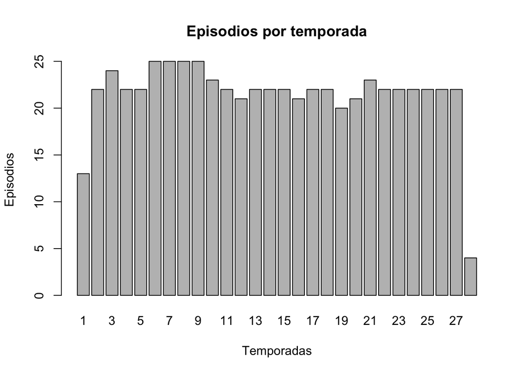

```r
barplot(
  episode_list$n,
  names.arg = episode_list$season,
  main="Episodios por temporada",
  xlab="Temporadas",
  ylab="Episodios"
)
```

## Clase 7

Carga de base de datos

```r
library(readxl)
Base <- read_excel("./Obligatorio.xlsx")
Base
```

```
## # A tibble: 50,000 x 19
##       ID Apellido Nombre sexo   Edad Localidad Segmento Ingresos
##    <dbl> <chr>    <chr>  <chr> <dbl>     <dbl>    <dbl>    <dbl>
##  1     1 PIAGGIO  MARIA  M         1         1        1   21171.
##  2     1 PIAGGIO  MARIA  M         1         1        1   21171.
##  3     1 PIAGGIO  MARIA  M         1         1        1   21171.
##  4     1 PIAGGIO  MARIA  M         1         1        1   21171.
##  5     2 GAGLIANO ELIZA… M         1         2        1   14802.
##  6     2 GAGLIANO ELIZA… M         1         2        1   14802.
##  7     2 GAGLIANO ELIZA… M         1         2        1   14802.
##  8     2 GAGLIANO ELIZA… M         1         2        1   14802.
##  9     3 DURAN    ANA    M         1         1        2   22514.
## 10     3 DURAN    ANA    M         1         1        2   22514.
## # … with 49,990 more rows, and 11 more variables: Fecha <dttm>,
## #   Producto <dbl>, Tasa <dbl>, Prestamo <dbl>, Atraso <dbl>,
## #   Importe_Cuota <dbl>, Saldo_Capital <dbl>, Capital_Pagado <dbl>,
## #   Saldo_Intereses <dbl>, Intereses_Pagos <dbl>, Cuotas_Pagas <dbl>
```

Cambiar las categorias a texto –> factor

```r
Base$Edad=factor(Base$Edad,labels = c('18-30','30-45','45-60','>60'))
```

¿Que problema tiene la base?

> R: Multiples observaciones en un solo conjunbto

```r
Base1 <- Base %>%
  select(ID,Apellido,Nombre,sexo,Edad,Localidad,Segmento,Ingresos) %>%
  unique %>%
  print
```

```
## # A tibble: 10,515 x 8
##       ID Apellido   Nombre    sexo  Edad  Localidad Segmento Ingresos
##    <dbl> <chr>      <chr>     <chr> <fct>     <dbl>    <dbl>    <dbl>
##  1     1 PIAGGIO    MARIA     M     18-30         1        1   21171.
##  2     2 GAGLIANO   ELIZABETH M     18-30         2        1   14802.
##  3     3 DURAN      ANA       M     18-30         1        2   22514.
##  4     4 QUEVEDO    SILVIA    M     18-30         1        2   17779.
##  5     5 CASTRO     ALICIA    M     18-30         1        2   24102.
##  6     6 GIANECHINI CELIA     M     18-30         1        2   20201.
##  7     7 CAMACHO    ADRIANA   M     18-30         1        2   23917.
##  8     8 ASENJO     RITA      M     18-30         1        2   22194.
##  9     9 LARREA     GUALBERTO M     18-30         1        2   19254.
## 10    10 D'ANDRAIA  ROBERTO   M     18-30         1        2   23591.
## # … with 10,505 more rows
```

Calculo de previsiones

```r
Base2<-Base %>%
  group_by(ID) %>%
  summarize(CR=sum(Saldo_Capital),
            MA=max(Atraso),
            Prev=CR*case_when(MA<=10 ~ 0.005,MA<=30 ~ 0.015,MA<=60 ~ 0.03,MA<=120 ~ 0.17,MA<=180 ~ 0.5,MA>180 ~ 1))
Base2
```

```
## # A tibble: 10,515 x 4
##       ID      CR    MA   Prev
##    <dbl>   <dbl> <dbl>  <dbl>
##  1     1 275602.    34  8268.
##  2     2 232758.     0  1164.
##  3     3 184071.     0   920.
##  4     4 164913.    95 28035.
##  5     5 165173.   123 82587.
##  6     6 242384.    64 41205.
##  7     7  50565.    64  8596.
##  8     8 161793.    34  4854.
##  9     9 171477.   123 85738.
## 10    10 203222.     0  1016.
## # … with 10,505 more rows
```

No se que calcula esta operación

```r
sum(Base2$Prev)/sum(Base2$CR)
```

```
## [1] 0.1805182
```